# CLASE Parameter Recovery Exercise

## Visualizing simulated choice probabilities and binary choices

Plot choice probabilities and binary choices as a sanity check that code correctly generates choices.

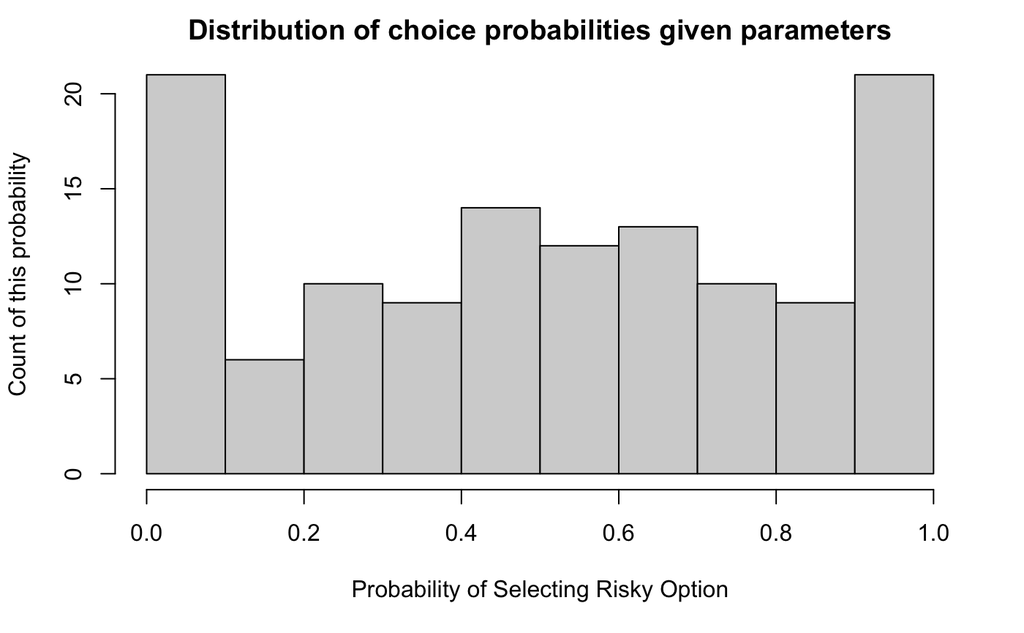

```r
example_parameters = c(.89, 1.8, 30);

example_choice_probability = choice_probability(choiceset,example_parameters);
example_choice_binarychoices = binary_choice_from_probability(example_choice_probability);

example_choice_dataframe = data.frame(choiceset, example_choice_probability, example_choice_binarychoices);

# Plot histogram of choice probabilities to see how variable choices are predicted to be.
hist(example_choice_probability,xlab = 'Probability of Selecting Risky Option', ylab = 'Count of this probability', main = 'Distribution of choice probabilities given parameters');
```

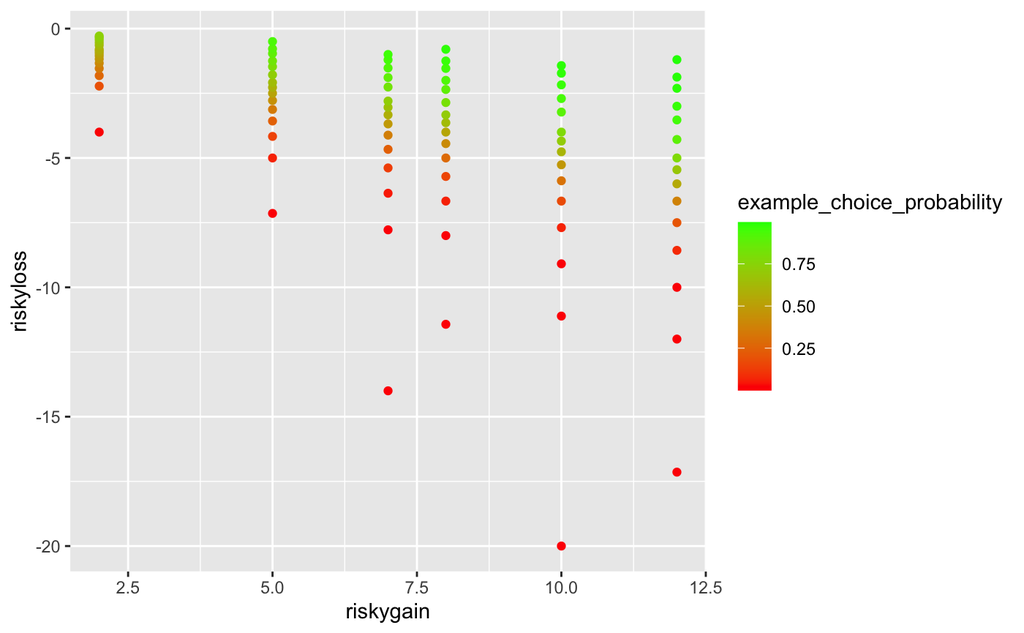

```r
# Plot p(choose risky option) given parameters as a function of choice values
example_probabilistic_gainloss_plot = ggplot(data = example_choice_dataframe[example_choice_dataframe$certainalternative == 0,], aes(x = riskygain, y = riskyloss)) +
  geom_point(aes(color = example_choice_probability)) +
  scale_colour_gradient(low='red',high='green');
print(example_probabilistic_gainloss_plot);
```

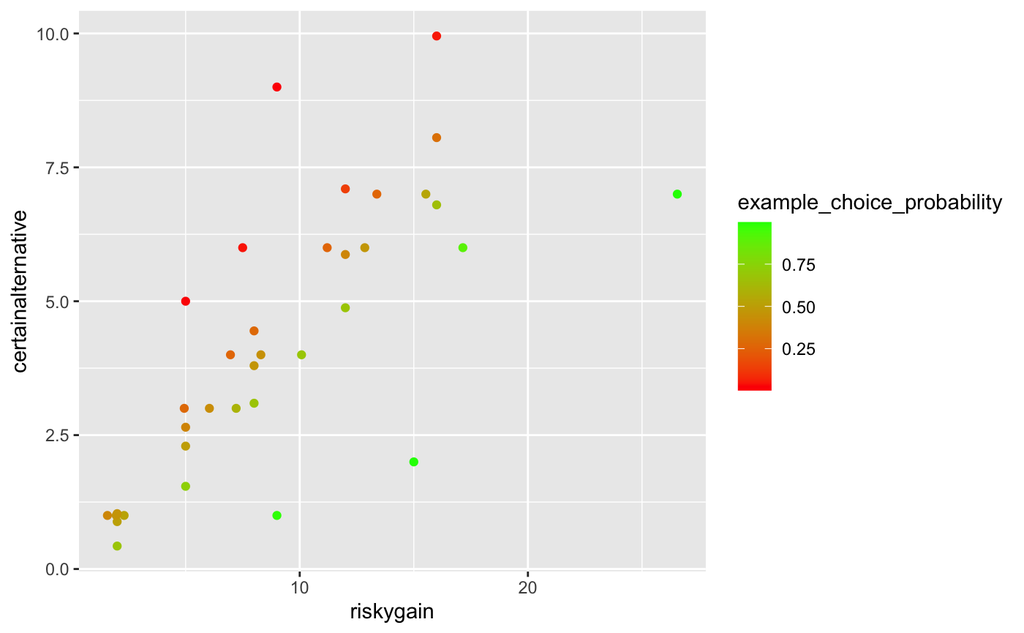

```r
example_probabilistic_gainonly_plot = ggplot(data = example_choice_dataframe[example_choice_dataframe$certainalternative > 0,], aes(x = riskygain, y = certainalternative)) +
  geom_point(aes(color = example_choice_probability)) +
  scale_colour_gradient(low='red',high='green');
print(example_probabilistic_gainonly_plot);
```

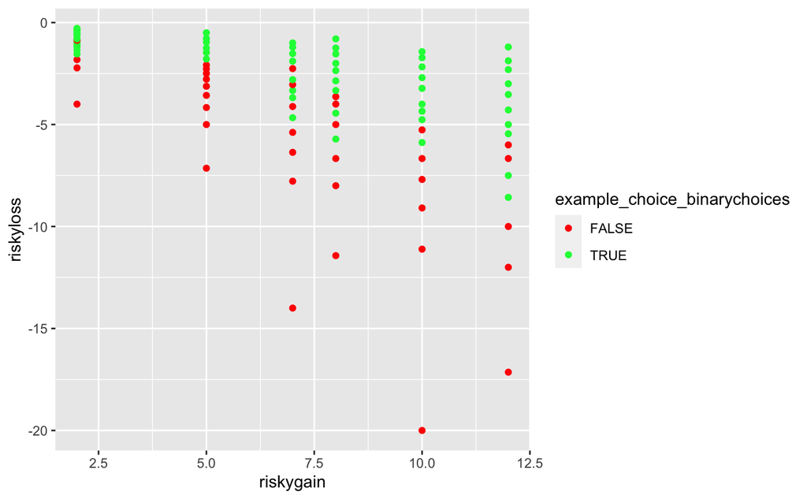

```r
# Plot simulated binary choices given parameters as a function of choice values
example_binary_gainloss_plot = ggplot(data = example_choice_dataframe[example_choice_dataframe$certainalternative == 0,], aes(x = riskygain, y = riskyloss)) +
  geom_point(aes(color = example_choice_binarychoices)) +
  scale_color_manual(values = c('#ff0000','#00ff44'));
print(example_binary_gainloss_plot);
```

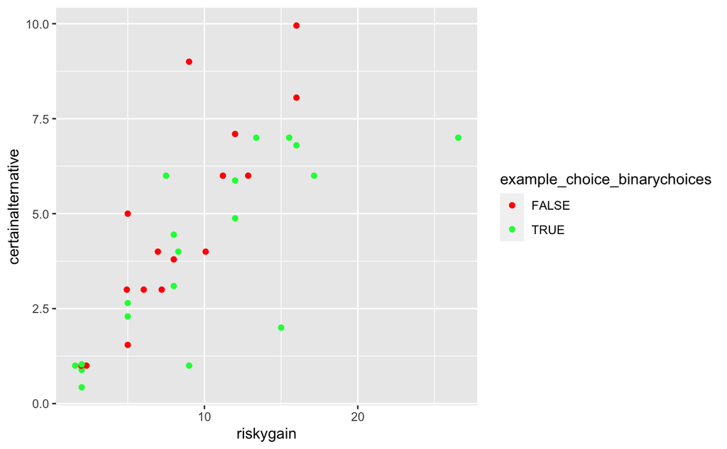

```r
example_binary_gainonly_plot = ggplot(data = example_choice_dataframe[example_choice_dataframe$certainalternative > 0,], aes(x = riskygain, y = certainalternative)) +
  geom_point(aes(color = example_choice_binarychoices)) +
  scale_color_manual(values = c('#ff0000','#00ff44'));
print(example_binary_gainonly_plot);
```

# Parameter Recovery Operations

## Step 1: Simulate Choice Data

```r
simulation_start_time = proc.time()[[3]];

simulated_choice_data = array(data = NA, dim = c(number_of_choices, simulations_per_subject, number_of_subjects));

for (subject in 1:number_of_subjects){
  temp_choice_probability = choice_probability(choiceset,truevals[subject,]);
  for (simulation in 1:simulations_per_subject){
    simulated_choice_data[,simulation,subject] = binary_choice_from_probability(temp_choice_probability);
  }
}

simulation_time_elapsed = proc.time()[[3]] - simulation_start_time
```

## Step 2: Use simulated choices to estimate parameter values

This step is expected to **take some time**.

```r
set.seed(Sys.time()); # Estimation procedure is sensitive to starting values

initial_values_lowerbound = c(0.2, 0.2, 1); # for rho, lambda, and mu
initial_values_upperbound = c(1.5, 5, 20) - initial_values_lowerbound; # for rho, lambda, and mu

estimation_lowerbound = c(eps,eps,eps);
estimation_upperbound = c(2, 8, 200);

recovered_parameters = array(dim = c(number_of_subjects, number_of_parameters, simulations_per_subject));
recovered_parameter_errors = array(dim = c(number_of_subjects, number_of_parameters, simulations_per_subject));
recovered_nlls = array(dim = c(number_of_subjects, simulations_per_subject));

progress_bar = txtProgressBar(min = 0, max = number_of_subjects, style = 3)
n.cores <- parallel::detectCores() - 1;
my.cluster <- parallel::makeCluster(
  n.cores,
  type = "FORK"
  )
doParallel::registerDoParallel(cl = my.cluster)


estimation_start_time = proc.time()[[3]];

for (subject in 1:number_of_subjects){
  for (simulation in 1:simulations_per_subject){

    # Placeholders for all the iterations of estimation we're doing
    all_estimates = matrix(nrow = iterations_per_estimation, ncol = number_of_parameters);
    all_nlls = matrix(nrow = iterations_per_estimation, ncol = 1);
    all_hessians = array(dim = c(iterations_per_estimation, number_of_parameters, number_of_parameters))

    # for (iteration in 1:iterations_per_estimation){
    #   initial_values = runif(3)*initial_values_upperbound + initial_values_lowerbound;
    #
    #   output <- optim(initial_values, negLLprospect, choiceset = choiceset, choices = simulated_choice_data[,simulation,subject], method = "L-BFGS-B", lower = estimation_lowerbound, upper = estimation_upperbound, hessian = TRUE);
    #
    #   all_estimates[iteration,] = output$par;
    #   all_nlls[iteration] = output$value;
    #   all_hessians[iteration,,] = output$hessian;
    #
    # }

    alloutput <- foreach(iteration=1:iterations_per_estimation, .combine=rbind) %dopar% {
      initial_values = runif(3)*initial_values_upperbound + initial_values_lowerbound;

      output <- optim(initial_values, negLLprospect, choiceset = choiceset, choices = simulated_choice_data[,simulation,subject], method = "L-BFGS-B", lower = estimation_lowerbound, upper = estimation_upperbound, hessian = TRUE);

      c(output$par,output$value);
    }

    all_estimates = alloutput[,1:3];
    all_nlls = alloutput[,4];

    best_nll_index = which.min(all_nlls); # identify the single best estimation

    recovered_parameters[subject,,simulation] = all_estimates[best_nll_index,];
    recovered_nlls[subject, simulation] = all_nlls[best_nll_index];

    # recovered_parameter_errors[subject,,simulation] = sqrt(diag(solve(all_hessians[best_nll_index,,])));

    best_hessian = hessian(func=negLLprospect, x = all_estimates[best_nll_index,], choiceset = choiceset, choices = simulated_choice_data[,simulation,subject])
    recovered_parameter_errors[subject,,simulation] = sqrt(diag(solve(best_hessian)));
  }
  setTxtProgressBar(progress_bar, subject)
}
```

```
NaNs produced
```

```
NaNs produced
```

```
NaNs produced
```

```
NaNs produced
```

```
NaNs produced
```

```
NaNs produced
```

```r
close(progress_bar)
```

```r
parallel::stopCluster(cl = my.cluster)

estimation_time_elapsed = proc.time()[[3]] - estimation_start_time;
```

## Step 3: Evaluate success

Evaluate how well original parameters were recovered.

### Plot recovered values against ground truth values

```r
mean_recovered_parameters = apply(recovered_parameters,c(1,2),mean); # take mean on the 3rd dimension (simulations of a single 'individual')
colnames(mean_recovered_parameters) <- c('recovered_rho','recovered_lambda','recovered_mu')

parameters_df = data.frame(truevals,mean_recovered_parameters);
```

[output not shown]

### Examine 95% CIs of estimated parameters

Second, look at the 95% confidence intervals for the estimated parameters, and quantify how often the ground truth parameters are included in that interval (should be roughly 95% of the time).

```r
conf_interval_zscore = 1.96; # the value to multiply the SE by to calculate the 95% CI, given parameter point estimate & SE

upper_bound = recovered_parameters + conf_interval_zscore * recovered_parameter_errors;
lower_bound = recovered_parameters - conf_interval_zscore * recovered_parameter_errors;

is_in_confidence_interval = array(dim=dim(recovered_parameters));

for(simulation in 1:simulations_per_subject){
  is_in_confidence_interval[,,simulation] = (truevals < upper_bound[,,simulation]) & (truevals > lower_bound[,,simulation]);
}

percent_accurately_recovered = mean(is_in_confidence_interval,na.rm=T) # na.rm req. b/c sometimes hessian is indeterminate (is not at a true minimum)

sum(is.na(is_in_confidence_interval)) # how many NAs are there
```

```
[1] 16
```

```r
sum(is.na(is_in_confidence_interval))/prod(dim(is_in_confidence_interval)) # fraction (0:1) that is NA
```

```
[1] 0.0008080808
```

The procedure resulted in an overall accuracy of parameter recovery of 94.84, over 19800 total simulations (we expect ~95%).

### Look at the actual estimates for a fairly typical participant

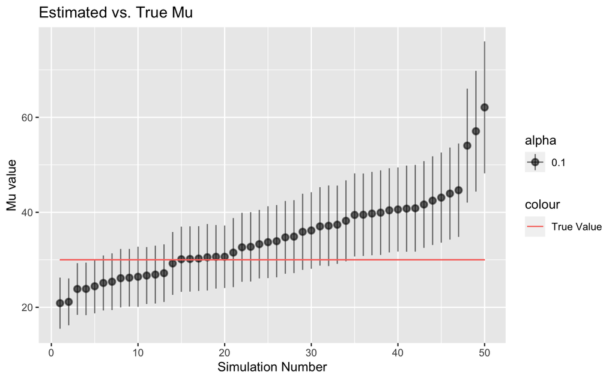

Ran a version with 3 values of rho (0.8, 0.95, 1.1), 10 values of lambda (0.8, 1, 1.2, 1.4, 1.6, 1.8, 2, 2.5, 3.5, 5), and 3 values of mu (10, 30, 100), which makes a total of 90 ‘subjects’; 25 simulations per subject; and 30 iterations of the MLE estimation procedure when fitting. This took roughly one hour to get estimates for each of the 6,750 parameter values (90 subjects, 3 parameter values/individual, and 25 simulations/subject), and those estimates (and errors) had an overall accuracy of 94.70% (expecting ~95%), meaning that the *true value* of the parameter was within the 95% confidence interval of the estimated value 94.70% of the time.